# Nora Master Project Data Analysis Notebook

## Q3.13 Source of Current Inflation

Which source do you rely on to inform yourself about the current value of inflation?  
Variable: categorical  
Method: convert to list and count + chi-squared test  
**Result: Fail to reject the null hypothesis**

```r
q3_13_table <- rawdata_value[, c("Q3.13", "group")]
q3_13_table$Q3.13 <- lapply(q3_13_table$Q3.13, function(x) as.list(as.numeric(strsplit(x, ",")[[1]])))
# count the number of occurrences of each value
q3_13_prop <- q3_13_table %>%
  unnest(Q3.13) %>%
  group_by(group,`Q3.13`) %>%
  summarise(count = n(), .groups = 'drop')
q3_13_prop$Q3.13 <- as.numeric(q3_13_prop$Q3.13)
# create a contingency table
q3_13_contingency <- xtabs(count ~ `Q3.13` + group, data = q3_13_prop)
print(q3_13_contingency)
```

```
     group
Q3.13 0-controlled 1-errorbar 2-shadedbar 3-fanchartslice 4-bellcurve
    1           40         42          33              39          33
    2           12         17          15              13          13
    3           21         26          22              26          21
    4            4          7           8               4          10
    5           15         16          25              19          19
    6            6          6           5               3           8
    7           13         11          15              15          12
    8            4          8           3               3           1
    9            3          0           0               0           0
```

```r
# Chi-squared test
chisq.test(q3_13_contingency)
```

```
    Pearson's Chi-squared test

data:  q3_13_contingency
X-squared = 32.784, df = 32, p-value = 0.4284
```

Plot source of current inflation proportion bar plot across different groups

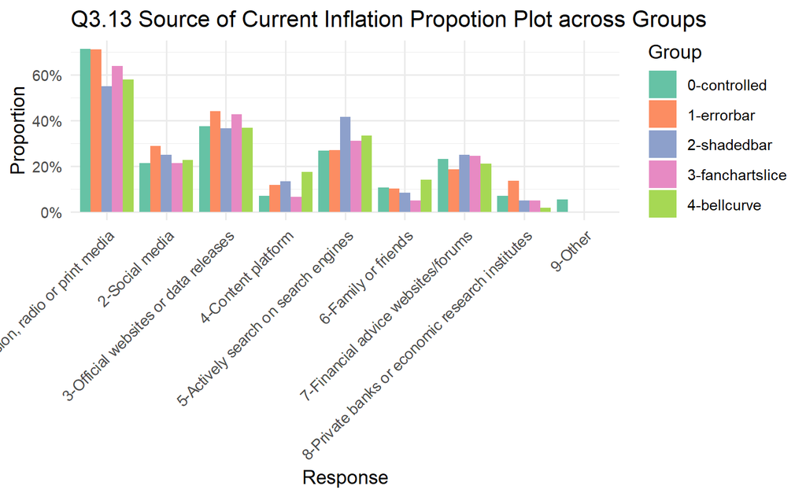

```r
# convert contingency table to data frame
q3_13_prop <- as.data.frame(q3_13_contingency) %>%
  left_join(group_total, by = "group") %>%
  mutate(Proportion = Freq / n_respondents)

# add a labelled column
q3_13_prop <- q3_13_prop %>%
  mutate(Q3.13_label = case_when(
    `Q3.13` == "1" ~ "1-Television, radio or print media",
    `Q3.13` == "2" ~ "2-Social media",
    `Q3.13` == "3" ~ "3-Official websites or data releases",
    `Q3.13` == "4" ~ "4-Content platform",
    `Q3.13` == "5" ~ "5-Actively search on search engines",
    `Q3.13` == "6" ~ "6-Family or friends",
    `Q3.13` == "7" ~ "7-Financial advice websites/forums",
    `Q3.13` == "8" ~ "8-Private banks or economic research institutes",
    `Q3.13` == "9" ~ "9-Other"
  ))
ggplot(q3_13_prop, aes(x = factor(`Q3.13_label`), y = Proportion, fill = group)) +
  geom_col(position = "dodge") +
  labs(
    title = "Q3.13 Source of Current Inflation Propotion Plot across Groups",
    x = "Response",
    y = "Proportion",
    fill = "Group"
  ) +
   scale_fill_brewer(palette = "Set2")+
  scale_y_continuous(labels = scales::percent_format(accuracy = 1)) +
  theme_minimal() +
  theme(axis.text.x = element_text(angle = 45, hjust = 1))
```

Plot percentage bar chart including all participants

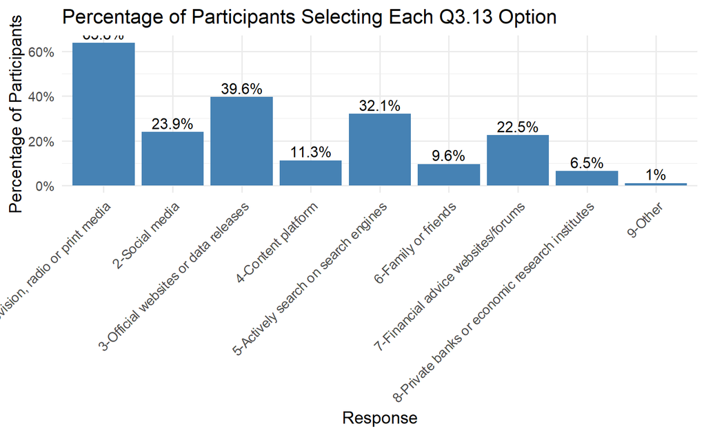

```r
q3_13_summary <- q3_13_prop %>%
  group_by(`Q3.13_label`) %>%
  summarise(total_count = sum(Freq), .groups = "drop") %>%
  mutate(proportion = total_count / total_respondents)

ggplot(q3_13_summary, aes(x = factor(Q3.13_label), y = proportion)) +
  geom_col(fill = "steelblue") +
  geom_text(aes(label = paste0(round(proportion * 100, 1), "%")),
            vjust = -0.3, size = 3.5) +
  scale_y_continuous(labels = scales::percent_format(accuracy = 1)) +
  labs(
    title = "Percentage of Participants Selecting Each Q3.13 Option",
    x = "Response",
    y = "Percentage of Participants"
  ) +
  theme_minimal() +
  theme(axis.text.x = element_text(angle = 45, hjust = 1))
```

## Q3.14 Impact of Current Inflation

To what extent do you feel that the current value of inflation is impacting your personal finances? Variable: categorical  
Method: contingency table + chi-squared test  
**Result: Fail to reject the null hypothesis**

```r
# Initial Check
summary(as.numeric(rawdata_value$Q3.14))
```

```
   Min. 1st Qu.  Median    Mean 3rd Qu.    Max.
  1.000   2.000   3.000   2.826   3.000   4.000
```

```r
q3_14_table <- rawdata_value[, c("Q3.14", "group")]
q3_14_contingency <- table(q3_14_table$Q3.14, q3_14_table$group)
print(q3_14_contingency)
```

```
    0-controlled 1-errorbar 2-shadedbar 3-fanchartslice 4-bellcurve
  1            3          0           4               0           1
  2           22         18          19              19          18
  3           22         30          25              28          23
  4            9         11          12              14          15
```

```r
# Chi-squared test
chisq.test(q3_14_contingency)
```

```
    Pearson's Chi-squared test

data:  q3_14_contingency
X-squared = 12.14, df = 12, p-value = 0.4345
```

Impact of Current Inflation proportion bar plot across different groups

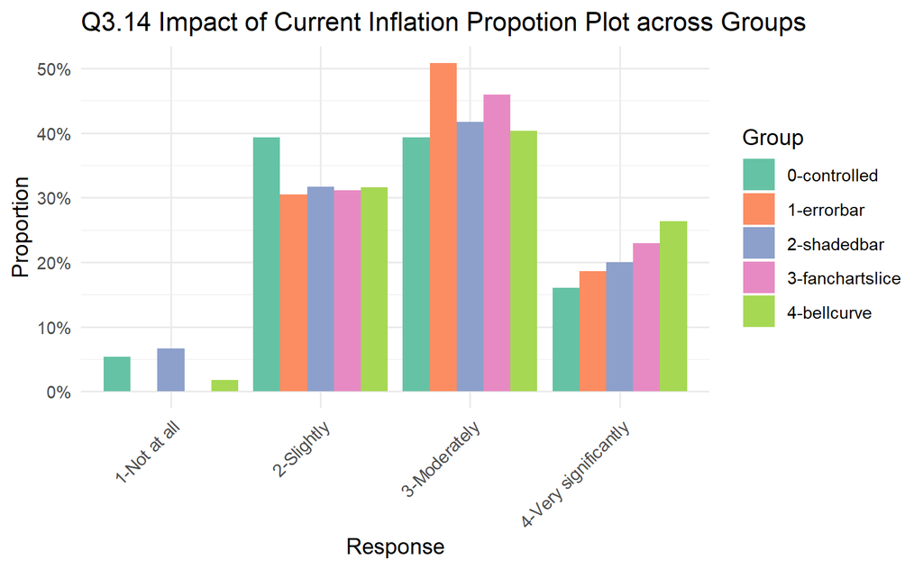

```r
q3_14_prop  <- as.data.frame(q3_14_contingency)
# rename columns
names(q3_14_prop) <- c("Q3.14", "Group", "Count")
# add a labelled column
q3_14_prop <- q3_14_prop %>%
  mutate(Q3.14_label = case_when(
    Q3.14 == "1" ~ "1-Not at all",
    Q3.14 == "2" ~ "2-Slightly",
    Q3.14 == "3" ~ "3-Moderately",
    Q3.14 == "4" ~ "4-Very significantly"
  ))
# calculate proportions within each group
q3_14_prop <- q3_14_prop %>%
  group_by(Group) %>%
  mutate(Proportion = Count / sum(Count))
ggplot(q3_14_prop, aes(x = as.factor(`Q3.14_label`), y = Proportion, fill = Group)) + geom_col(position = "dodge") +
  labs(
    title = "Q3.14 Impact of Current Inflation Propotion Plot across Groups",
    x = "Response",
    y = "Proportion"
  ) +
   scale_fill_brewer(palette = "Set2")+
  scale_y_continuous(labels = scales::percent_format(accuracy = 1)) +
  theme_minimal()+
  theme(axis.text.x = element_text(angle = 45, hjust = 1))
```

Plot pie chart including all participants

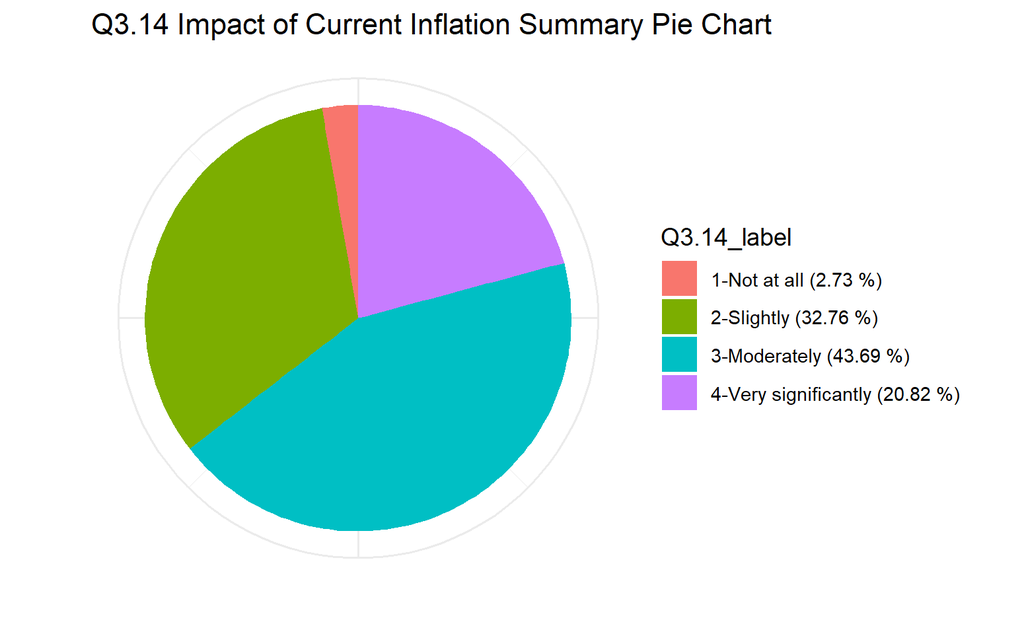

```r
q3_14_summary <- q3_14_prop %>%
  group_by(`Q3.14_label`) %>%
  summarise(total_count = sum(Count), .groups = "drop") %>%
  mutate(proportion = total_count / sum(total_count),
        `Q3.14_label` = paste0(`Q3.14_label`, " (", round(proportion * 100, 2), " %)"))
ggplot(q3_14_summary, aes(x = "",y = proportion, fill = `Q3.14_label`)) +
  geom_col(width = 1) +
  coord_polar(theta = "y") +
  labs(title = "Q3.14 Impact of Current Inflation Summary Pie Chart",
       x = "",
       y = "") +
  theme_minimal() +
  theme(axis.text.x = element_blank())
```

## Q3.15 Response to Current Inflation

How much do you adjust or take action in response to the change in current value of inflation?  
Variable: categorical  
Method: contingency table + chi-squared test  
**Result: Fail to reject the null hypothesis**

```r
# Initial Check
summary(as.numeric(rawdata_value$Q3.15))
```

```
   Min. 1st Qu.  Median    Mean 3rd Qu.    Max.
  1.000   2.000   3.000   2.519   3.000   4.000
```

```r
q3_15_table <- rawdata_value[, c("Q3.15", "group")]
q3_15_contingency <- table(q3_15_table$Q3.15, q3_15_table$group)
print(q3_15_contingency)
```

```
    0-controlled 1-errorbar 2-shadedbar 3-fanchartslice 4-bellcurve
  1            8          2           8               9           7
  2           25         20          22              14          20
  3           18         29          23              34          26
  4            5          8           7               4           4
```

```r
# Chi-squared test
chisq.test(q3_15_contingency)
```

```
    Pearson's Chi-squared test

data:  q3_15_contingency
X-squared = 15.333, df = 12, p-value = 0.2237
```

Response to Current Inflation proportion bar plot across different groups

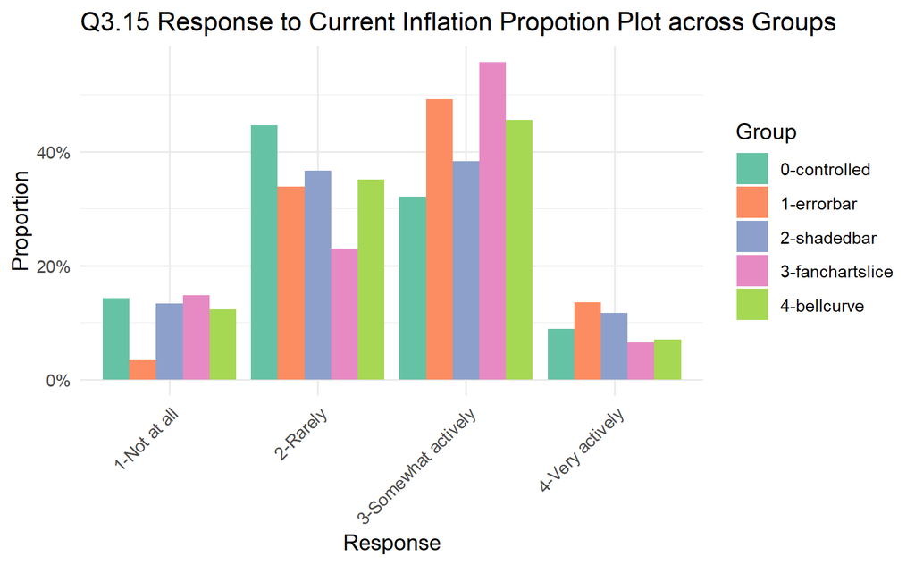

```r
q3_15_prop  <- as.data.frame(q3_15_contingency)
# rename columns
names(q3_15_prop) <- c("Q3.15", "Group", "Count")
# add a labelled column
q3_15_prop <- q3_15_prop %>%
  mutate(Q3.15_label = case_when(
    Q3.15 == "1" ~ "1-Not at all",
    Q3.15 == "2" ~ "2-Rarely",
    Q3.15 == "3" ~ "3-Somewhat actively",
    Q3.15 == "4" ~ "4-Very actively"
  ))
# calculate proportions within each group
q3_15_prop <- q3_15_prop %>%
  group_by(Group) %>%
  mutate(Proportion = Count / sum(Count))
ggplot(q3_15_prop, aes(x = as.factor(`Q3.15_label`), y = Proportion, fill = Group)) + geom_col(position = "dodge") +
  labs(
    title = "Q3.15 Response to Current Inflation Propotion Plot across Groups",
    x = "Response",
    y = "Proportion"
  ) +
   scale_fill_brewer(palette = "Set2")+
  scale_y_continuous(labels = scales::percent_format(accuracy = 1)) +
  theme_minimal()+
  theme(axis.text.x = element_text(angle = 45, hjust = 1))
```

Plot pie chart including all participants

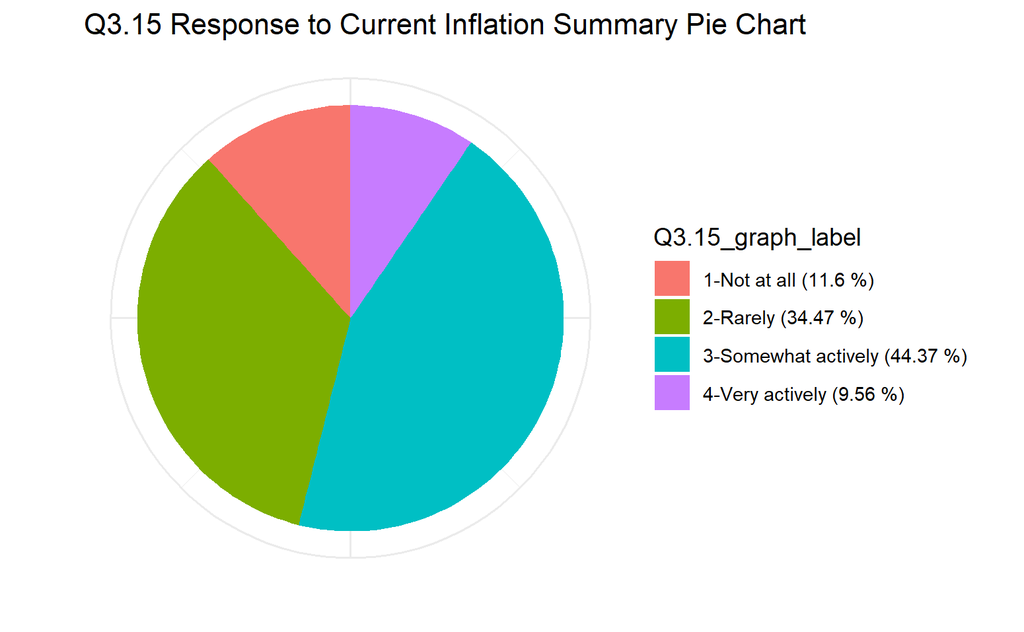

```r
q3_15_summary <- q3_15_prop %>%
  group_by(`Q3.15_label`) %>%
  summarise(total_count = sum(Count), .groups = "drop") %>%
  mutate(proportion = total_count / sum(total_count),
         `Q3.15_graph_label` = paste0(`Q3.15_label`, " (", round(proportion * 100, 2), " %)"))
ggplot(q3_15_summary, aes(x = "",y = proportion, fill = `Q3.15_graph_label`)) +
  geom_col(width = 1) +
  coord_polar(theta = "y") +
  labs(title = "Q3.15 Response to Current Inflation Summary Pie Chart",
       x = "",
       y = "") +
  theme_minimal() +
  theme(axis.text.x = element_blank())
```

## Q3.16 Frequency of Checking Inflation Forecasts

How often do you look at inflation forecasts (that is, information about future inflation)?  
Variable: categorical  
Method: contingency table + chi-squared test  
**Result: Fail to reject the null hypothesis**

```r
# Initial Check
summary(as.numeric(rawdata_value$Q3.16))
```

```
   Min. 1st Qu.  Median    Mean 3rd Qu.    Max.
  1.000   2.000   2.000   2.167   3.000   4.000
```

```r
q3_16_table <- rawdata_value[, c("Q3.16", "group")]
q3_16_contingency <- table(q3_16_table$Q3.16, q3_16_table$group)
print(q3_16_contingency)
```

```
    0-controlled 1-errorbar 2-shadedbar 3-fanchartslice 4-bellcurve
  1            9         14          15              12           9
  2           35         23          23              27          32
  3            7         19          20              18          16
  4            5          3           2               4           0
```

```r
# Chi-squared test
chisq.test(q3_16_contingency)
```

```
    Pearson's Chi-squared test

data:  q3_16_contingency
X-squared = 19.045, df = 12, p-value = 0.08745
```

Frequency of Checking Inflation Forecasts proportion bar plot across different groups

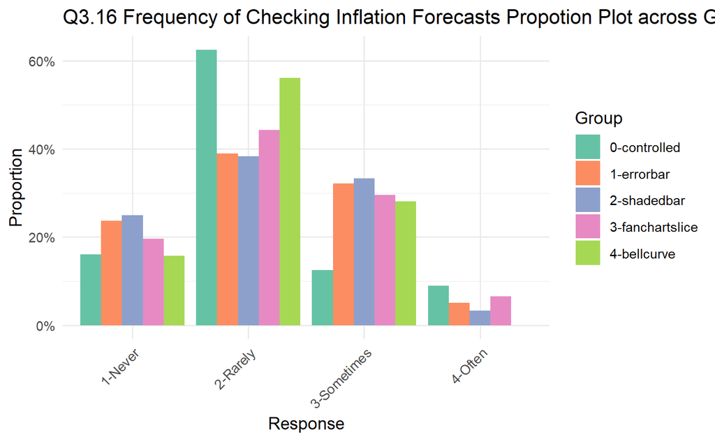

```r
q3_16_prop  <- as.data.frame(q3_16_contingency)
# rename columns
names(q3_16_prop) <- c("Q3.16", "Group", "Count")
# add a labelled column
q3_16_prop <- q3_16_prop %>%
  mutate(Q3.16_label = case_when(
    Q3.16 == "1" ~ "1-Never",
    Q3.16 == "2" ~ "2-Rarely",
    Q3.16 == "3" ~ "3-Sometimes",
    Q3.16 == "4" ~ "4-Often"
  ))
# calculate proportions within each group
q3_16_prop <- q3_16_prop %>%
  group_by(Group) %>%
  mutate(Proportion = Count / sum(Count))
ggplot(q3_16_prop, aes(x = as.factor(`Q3.16_label`), y = Proportion, fill = Group)) + geom_col(position = "dodge") +
  labs(
    title = "Q3.16 Frequency of Checking Inflation Forecasts Propotion Plot across Groups",
    x = "Response",
    y = "Proportion"
  ) +
   scale_fill_brewer(palette = "Set2")+
  scale_y_continuous(labels = scales::percent_format(accuracy = 1)) +
  theme_minimal()+
  theme(axis.text.x = element_text(angle = 45, hjust = 1))
```

Plot pie chart including all participants

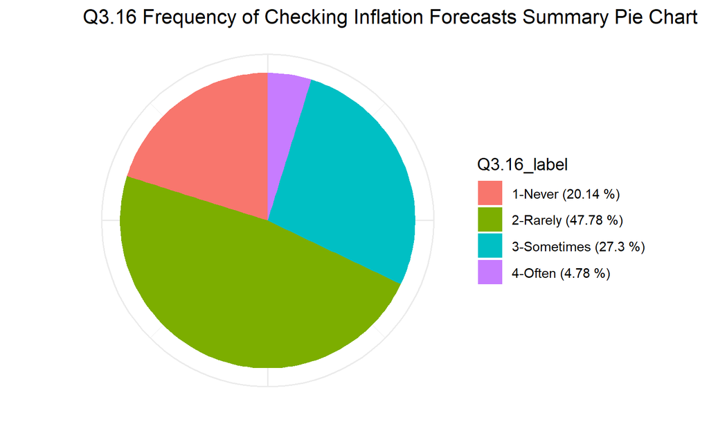

```r
q3_16_summary <- q3_16_prop %>%
  group_by(`Q3.16_label`) %>%
  summarise(total_count = sum(Count), .groups = "drop") %>%
  mutate(proportion = total_count / sum(total_count),
         `Q3.16_label` = paste0(`Q3.16_label`, " (", round(proportion * 100, 2), " %)"))
ggplot(q3_16_summary, aes(x = "",y = proportion, fill = `Q3.16_label`)) +
  geom_col(width = 1) +
  coord_polar(theta = "y") +
  labs(title = "Q3.16 Frequency of Checking Inflation Forecasts Summary Pie Chart",
       x = "",
       y = "") +
  theme_minimal() +
  theme(axis.text.x = element_blank())
```

## Q3.17 Source of Inflation Forecasts

Which source do you rely on to obtain inflation forecasts (information about future inflation)?  
Variable: categorical  
Method: convert to list and count + chi-squared test  
**Result: Fail to reject the null hypothesis**

```r
q3_17_table <- rawdata_value[, c("Q3.17", "group")]
q3_17_table$Q3.17 <- lapply(q3_17_table$Q3.17, function(x) as.list(as.numeric(strsplit(x, ",")[[1]])))
# count the number of occurrences of each value
q3_17_prop <- q3_17_table %>%
  unnest(Q3.17) %>%
  group_by(group,`Q3.17`) %>%
  summarise(count = n(), .groups = 'drop')
q3_17_prop$Q3.17 <- as.numeric(q3_17_prop$Q3.17)
# create a contingency table
q3_17_contingency <- xtabs(count ~ `Q3.17` + group, data = q3_17_prop)
print(q3_17_contingency)
```

```
     group
Q3.17 0-controlled 1-errorbar 2-shadedbar 3-fanchartslice 4-bellcurve
    1           35         31          34              31          31
    2           13         16          13              11          12
    3           15         21          22              24          25
    4            4          9           8               4           6
    5           14         17          19              16          14
    6            4          4           6               3           6
    7           13         15          16              17          15
    8            3          9           4               5           2
    9            2          0           0               0           0
```

```r
# Chi-squared test
chisq.test(q3_17_contingency)
```

```
    Pearson's Chi-squared test

data:  q3_17_contingency
X-squared = 23.655, df = 32, p-value = 0.8566
```

Plot source of inflation forecasts proportion bar plot across different groups

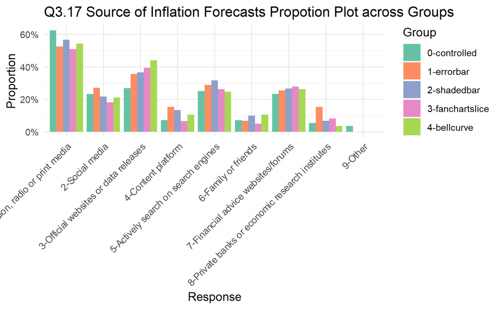

```r
# convert contingency table to data frame
q3_17_prop <- as.data.frame(q3_17_contingency) %>%
  left_join(group_total, by = "group") %>%
  mutate(Proportion = Freq / n_respondents)
# add a labelled column
q3_17_prop <- q3_17_prop %>%
  mutate(Q3.17_label = case_when(
    `Q3.17` == "1" ~ "1-Television, radio or print media",
    `Q3.17` == "2" ~ "2-Social media",
    `Q3.17` == "3" ~ "3-Official websites or data releases",
    `Q3.17` == "4" ~ "4-Content platform",
    `Q3.17` == "5" ~ "5-Actively search on search engines",
    `Q3.17` == "6" ~ "6-Family or friends",
    `Q3.17` == "7" ~ "7-Financial advice websites/forums",
    `Q3.17` == "8" ~ "8-Private banks or economic research institutes",
    `Q3.17` == "9" ~ "9-Other"
  ))
ggplot(q3_17_prop, aes(x = factor(`Q3.17_label`), y = Proportion, fill = group)) +
  geom_col(position = "dodge") +
  labs(
    title = "Q3.17 Source of Inflation Forecasts Propotion Plot across Groups",
    x = "Response",
    y = "Proportion",
    fill = "Group"
  ) +
   scale_fill_brewer(palette = "Set2")+
  scale_y_continuous(labels = scales::percent_format(accuracy = 1)) +
  theme_minimal() +
  theme(axis.text.x = element_text(angle = 45, hjust = 1))
```

Plot percentage bar chart including all participants

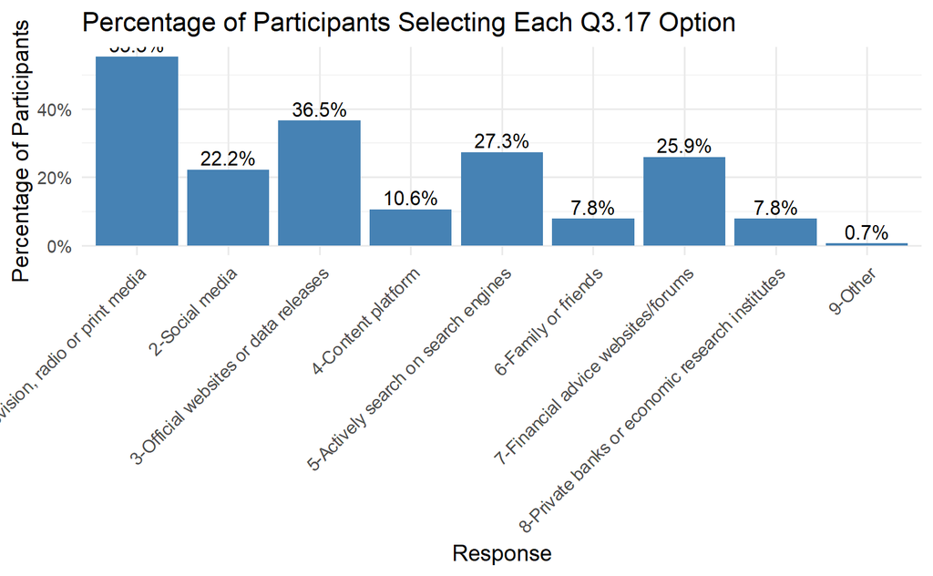

```r
q3_17_summary <- q3_17_prop %>%
  group_by(`Q3.17_label`) %>%
  summarise(total_count = sum(Freq), .groups = "drop") %>%
  mutate(proportion = total_count / total_respondents)
ggplot(q3_17_summary, aes(x = factor(Q3.17_label), y = proportion)) +
  geom_col(fill = "steelblue") +
  geom_text(aes(label = paste0(round(proportion * 100, 1), "%")),
            vjust = -0.3, size = 3.5) +
  scale_y_continuous(labels = scales::percent_format(accuracy = 1)) +
  labs(
    title = "Percentage of Participants Selecting Each Q3.17 Option",
    x = "Response",
    y = "Percentage of Participants"
  ) +
  theme_minimal() +
  theme(axis.text.x = element_text(angle = 45, hjust = 1))
```

## Q3.18 Impact of Inflation Forecasts

To what extent do you feel that inflation forecasts (information about future inflation) impact your personal finances?  
Variable: categorical  
Method: contingency table + chi-squared test  
**Result: Fail to reject the null hypothesis**

```r
# Initial Check
summary(as.numeric(rawdata_value$Q3.18))
```

```
   Min. 1st Qu.  Median    Mean 3rd Qu.    Max.
  1.000   2.000   2.000   2.321   3.000   4.000
```

```r
q3_18_table <- rawdata_value[, c("Q3.18", "group")]
q3_18_contingency <- table(q3_18_table$Q3.18, q3_18_table$group)
print(q3_18_contingency)
```

```
    0-controlled 1-errorbar 2-shadedbar 3-fanchartslice 4-bellcurve
  1           13          9          15               7           9
  2           22         29          17              29          24
  3           17         14          22              20          18
  4            4          7           6               5           6
```

```r
# Chi-squared test
chisq.test(q3_18_contingency)
```

```
    Pearson's Chi-squared test

data:  q3_18_contingency
X-squared = 10.822, df = 12, p-value = 0.5443
```

Impact of Inflation Forecasts proportion bar plot across different groups

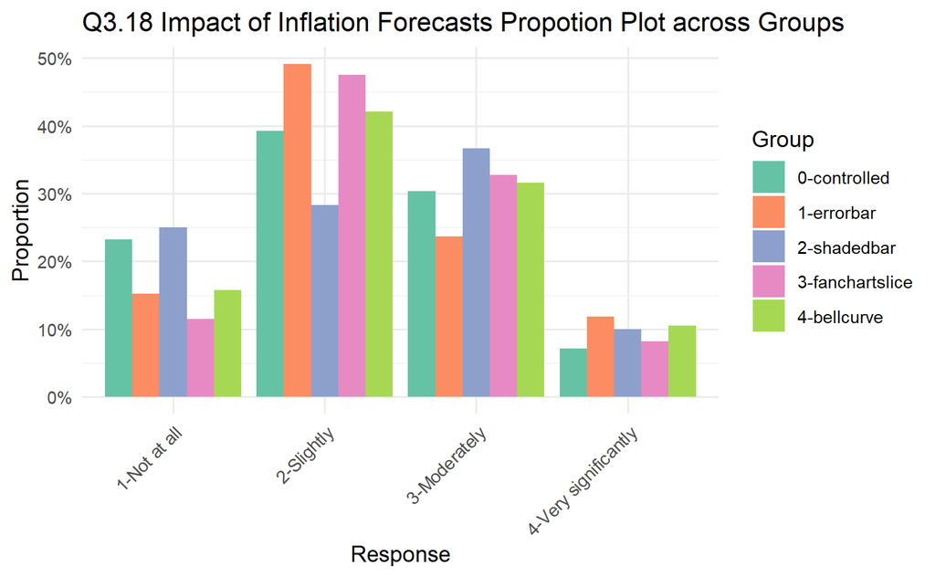

```r
q3_18_prop  <- as.data.frame(q3_18_contingency)
# rename columns
names(q3_18_prop) <- c("Q3.18", "Group", "Count")
# add a labelled column
q3_18_prop <- q3_18_prop %>%
  mutate(Q3.18_label = case_when(
    Q3.18 == "1" ~ "1-Not at all",
    Q3.18 == "2" ~ "2-Slightly",
    Q3.18 == "3" ~ "3-Moderately",
    Q3.18 == "4" ~ "4-Very significantly"
  ))
# calculate proportions within each group
q3_18_prop <- q3_18_prop %>%
  group_by(Group) %>%
  mutate(Proportion = Count / sum(Count))
ggplot(q3_18_prop, aes(x = as.factor(`Q3.18_label`), y = Proportion, fill = Group)) + geom_col(position = "dodge") +
  labs(
    title = "Q3.18 Impact of Inflation Forecasts Propotion Plot across Groups",
    x = "Response",
    y = "Proportion"
  ) +
   scale_fill_brewer(palette = "Set2")+
  scale_y_continuous(labels = scales::percent_format(accuracy = 1)) +
  theme_minimal()+
  theme(axis.text.x = element_text(angle = 45, hjust = 1))
```

Plot pie chart including all participants

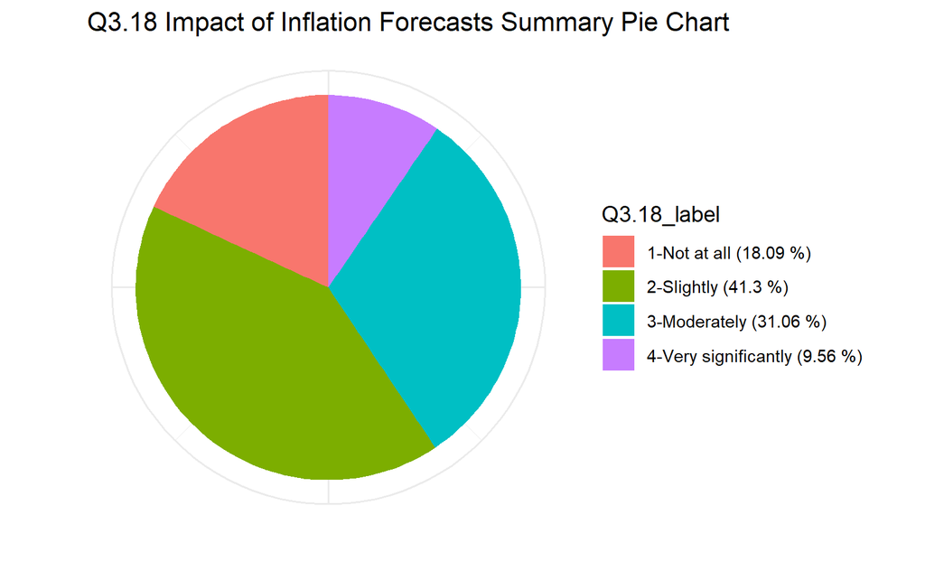

```r
q3_18_summary <- q3_18_prop %>%
  group_by(`Q3.18_label`) %>%
  summarise(total_count = sum(Count), .groups = "drop") %>%
  mutate(proportion = total_count / sum(total_count),
         `Q3.18_label` = paste0(`Q3.18_label`, " (", round(proportion * 100, 2), " %)"))
ggplot(q3_18_summary, aes(x = "",y = proportion, fill = `Q3.18_label`)) +
  geom_col(width = 1) +
  coord_polar(theta = "y") +
  labs(title = "Q3.18 Impact of Inflation Forecasts Summary Pie Chart",
       x = "",
       y = "") +
  theme_minimal() +
  theme(axis.text.x = element_blank())
```

## Q3.19 Response to Inflation Forecasts

How much do you adjust or take action in response to inflation forecasts (information about future inflation)?  
Variable: categorical  
Method: contingency table + chi-squared test  
**Result: Fail to reject the null hypothesis**

```r
# Initial Check
summary(as.numeric(rawdata_value$Q3.19))
q3_19_table <- rawdata_value[, c("Q3.19", "group")]
q3_19_contingency <- table(q3_19_table$Q3.19, q3_19_table$group)
print(q3_19_contingency)
# Chi-squared test
chisq.test(q3_19_contingency)
```

[output not shown]

Response to Inflation Forecasts proportion bar plot across different groups

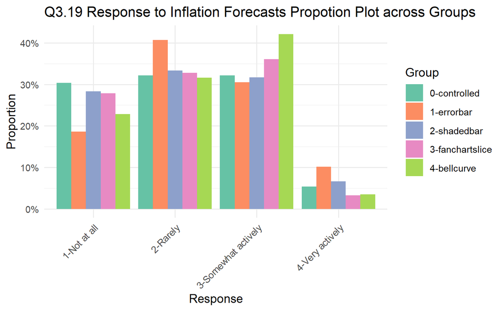

```r
q3_19_prop  <- as.data.frame(q3_19_contingency)
# rename columns
names(q3_19_prop) <- c("Q3.19", "Group", "Count")
# add a labelled column
q3_19_prop <- q3_19_prop %>%
  mutate(Q3.19_label = case_when(
    Q3.19 == "1" ~ "1-Not at all",
    Q3.19 == "2" ~ "2-Rarely",
    Q3.19 == "3" ~ "3-Somewhat actively",
    Q3.19 == "4" ~ "4-Very actively"
  ))
# calculate proportions within each group
q3_19_prop <- q3_19_prop %>%
  group_by(Group) %>%
  mutate(Proportion = Count / sum(Count))
ggplot(q3_19_prop, aes(x = as.factor(`Q3.19_label`), y = Proportion, fill = Group)) + geom_col(position = "dodge") +
  labs(
    title = "Q3.19 Response to Inflation Forecasts Propotion Plot across Groups",
    x = "Response",
    y = "Proportion"
  ) +
   scale_fill_brewer(palette = "Set2")+
  scale_y_continuous(labels = scales::percent_format(accuracy = 1)) +
  theme_minimal()+
  theme(axis.text.x = element_text(angle = 45, hjust = 1))
```

Plot pie chart including all participants

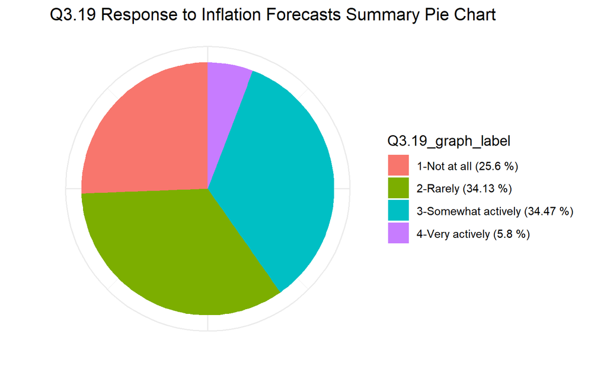

```r
q3_19_summary <- q3_19_prop %>%
  group_by(`Q3.19_label`) %>%
  summarise(total_count = sum(Count), .groups = "drop") %>%
  mutate(proportion = total_count / sum(total_count),
         `Q3.19_graph_label` = paste0(`Q3.19_label`, " (", round(proportion * 100, 2), " %)"))
ggplot(q3_19_summary, aes(x = "",y = proportion, fill = `Q3.19_graph_label`)) +
  geom_col(width = 1) +
  coord_polar(theta = "y") +
  labs(title = "Q3.19 Response to Inflation Forecasts Summary Pie Chart",
       x = "",
       y = "") +
  theme_minimal() +
  theme(axis.text.x = element_blank())
```

# Actual Survey Analysis

## ! Qxx.2 Graph Familarity

```r
chisq_result <- chisq.test(survey_q2_contingency)
chisq_result$stdres
```

```
    0-controlled 1-errorbar 2-shadedbar 3-fanchartslice 4-bellcurve
  N    -1.588275  -0.909674    2.477879        1.397084   -1.459834
  Y     1.588275   0.909674   -2.477879       -1.397084    1.459834
```

```r
yes_per <- survey_q2_contingency[2,]
no_per <- survey_q2_contingency[1,]
familarity_group_total <- colSums(survey_q2_contingency)
yes_prop <- yes_per/familarity_group_total
no_prop <- no_per/familarity_group_total
# convert to data frame
survey_q2_summary <-data.frame(yes_prop, no_prop)
```

Plot the graph

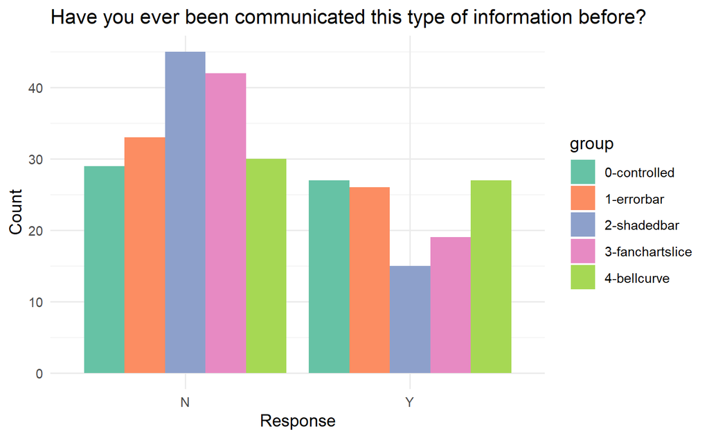

```r
ggplot(survey_q2, aes(x = q2_recode, fill = group)) +
  geom_bar(position = "dodge") +
  labs(title = "Have you ever been communicated this type of information before?",
       x = "Response",
       y = "Count") +
  scale_fill_brewer(palette = "Set2") +
  theme_minimal()
```

## Qxx.3 Prior Expectation

```r
# combine data from different groups
survey_q3 <- data.frame()
survey_q3_list <- list("Q4.3","Q6.3", "Q8.3", "Q10.3", "Q12.3")
for (i in seq_along(group_list)) {
  df <- group_list[[i]]
  col <- survey_q3_list[[i]]
  temp_table <- df[, c(col, "group")]
  names(temp_table) <- c("q3_value", "group")
  survey_q3 <- rbind(survey_q3, temp_table)
}
```

## Qxx.6 Probability of exactly 2.6%

what do you think is the probability of inflation being exactly 2.6%?  
Definitive Correct Answer  
*descending order*  
Method: contingency table + proportion test  
**Result: Fail to reject the null hypothesis** Is there any other test? maybe there is just no differences..

```r
# combine data from different groups
survey_q6 <- data.frame()
survey_q6_list <- list("Q4.6","Q6.6", "Q8.6", "Q10.6", "Q12.6")
for (i in seq_along(group_list)) {
  df <- group_list[[i]]
  col <- survey_q6_list[[i]]
  temp_table <- df[, c(col, "group")]
  names(temp_table) <- c("q6_value", "group")
  survey_q6 <- rbind(survey_q6, temp_table)
}

# run annova test--> still no significant differences
# anova_test <- aov(q6_value ~ group, data = survey_q6)
# summary(anova_test)


# run Kruskal-Wallis test--> still no significant differences
kruskal_test <- kruskal.test(q6_value ~ group, data = survey_q6)
print(kruskal_test)

# force order
# survey_q6$group <- factor(survey_q6$group, levels = c("controlled", "errorbar", "shadedbar", "fanchartslice", "bellcurve"))

survey_q6_contingency <- table(survey_q6$q6_value, survey_q6$group)
# whether one proportion differs across groups
less_than_1_per <- survey_q6_contingency[7,]
survey_q6_group_total <- colSums(survey_q6_contingency)
prop.test(less_than_1_per, survey_q6_group_total)
```

[output not shown]

## Qxx.8 Probability of between 3.3% and 5.6%

# Statistical Testing

## Basics

```r
chisq_result <- chisq.test(q3_4_contingency)
std_resid <- chisq_result$stdres
```

Cells with absolute value > ~2 (or > 1.96 for 95% confidence)indicate contributing most to the overall chi-squared

2. Pairwise proportion tests:

```r
pairwise.prop.test(
  x = q3_4_contingency[, 1:ncol(q3_4_contingency)],  # counts per group
  n = colSums(q3_4_contingency),                     # total per group
  p.adjust.method = "bonferroni"                     # or "holm", "BH"
)
```

## ANOVA test

```r
shapiro.test(df$value)
```

2. Homogeneity of variances across groups

```r
# Check the assumption of equal variances (homogeneity of variance) across groups
# If p< 0.05, we can reject the null hypothesis of equal variances, meaning the variances are significantly different across groups
bartlett.test(`Q3.2` ~ group, data = age_table) # if data is normally distributed
# Levene's test for homogeneity of variance if data may not be normally distributed
library(car)
leveneTest(value ~ group, data = time_duration_table)
```

### Post-hoc test

If ANOVA is significant, we can perform post-hoc tests to determine which groups are significantly different from each other.

```r
# post-hoc test
tukey_test <- TukeyHSD(anova_test)
print(tukey_test)
```

> Null hypothesis (H₀): All group means are equal  
> Alternative hypothesis (H₁): At least one group mean is different

## Kruskal-Wallis test

(non-parametric test)  
when the dependent variable is continuous or ordinal  
when the assumptions of one-way ANOVA are not met: normality and equal variances

```r
library(FSA)

dunnTest(value ~ group, data = df, method = "bonferroni")
#
```

## Propotion test -prop.test()

- prop.test(): at least one group differs
- pairwise.prop.test(): identifying which specific pairs of groups differ significantly in their proportions, choose the p.adjust.method = “holm” or “bonferroni” or “BH”